# FordGoBike System Data Exploratation

FordGoBike (later BayWheels) is a Bay Area bike sharing system. In this project, the trip data of FordGoBike from 2018 to 2019 will be explored.

**Import Packages**

```python
# import all packages and set plots to be embedded inline
import numpy as np
import pandas as pd
import matplotlib.pyplot as plt
import seaborn as sb
#packages for data gathering
import requests
from io import BytesIO
from zipfile import ZipFile
from bs4 import BeautifulSoup
import os
from selenium import webdriver
from webdriver_manager.chrome import ChromeDriverManager
from selenium.webdriver.support.ui import WebDriverWait
from selenium.webdriver.support import expected_conditions as EC
from selenium.webdriver.common.by import By
from selenium.common.exceptions import TimeoutException
%matplotlib inline
```

### Data Gathering

The data is available on 'https://s3.amazonaws.com/baywheels-data/index.html'. This data will be downloaded programmatically using the Selenium and Beautiful Soup packages and then read to a dataframe using requests library.

```python
#Extracting url info from index.html
driver = webdriver.Chrome(ChromeDriverManager().install())
driver.get('https://s3.amazonaws.com/baywheels-data/index.html')
try:
    WebDriverWait(driver, 10).until(EC.presence_of_element_located((By.CLASS_NAME, 'a')))
except TimeoutException:
    print('Page timed out after 10 secs.')
soup = BeautifulSoup(driver.page_source, 'html.parser')
tags=soup.find_all('a')
driver.quit()
```

```
[WDM] - Current google-chrome version is 83.0.4103
[WDM] - Get LATEST driver version for 83.0.4103
[WDM] - Driver [C:\Users\sushm\.wdm\drivers\chromedriver\win32\83.0.4103.39\chromedriver.exe] found in cache
```

```
Page timed out after 10 secs.
```

```python
#Downloading from the url and unzipping the folder
for tag in tags[:-1]:
    url=tag.get('href')
    response=requests.get(url)
    zip_file = ZipFile(BytesIO(response.content))
    zip_file.extractall('ford-data')
```

```python
path='ford-data'
os.listdir(path)
```

```
['2017-fordgobike-tripdata.csv',
 '201801-fordgobike-tripdata.csv',
 '201802-fordgobike-tripdata.csv',
 '201803-fordgobike-tripdata.csv',
 '201804-fordgobike-tripdata.csv',
 '201805-fordgobike-tripdata.csv',
 '201806-fordgobike-tripdata.csv',
 '201807-fordgobike-tripdata.csv',
 '201808-fordgobike-tripdata.csv',
 '201809-fordgobike-tripdata.csv',
 '201810-fordgobike-tripdata.csv',
 '201811-fordgobike-tripdata.csv',
 '201812-fordgobike-tripdata.csv',
 '201901-fordgobike-tripdata.csv',
 '201902-fordgobike-tripdata.csv',
 '201903-fordgobike-tripdata.csv',
 '201904-fordgobike-tripdata.csv',
 '201905-baywheels-tripdata.csv',
 '201906-baywheels-tripdata.csv',
 '201907-baywheels-tripdata.csv',
 '201908-baywheels-tripdata.csv',
 '201909-baywheels-tripdata.csv',
 '201910-baywheels-tripdata.csv',
 '201911-baywheels-tripdata.csv',
 '201912-baywheels-tripdata.csv',
 '202001-baywheels-tripdata.csv',
 '202002-baywheels-tripdata.csv',
 '202003-baywheels-tripdata.csv',
 '202004-baywheels-tripdata.csv',
 '202005-baywheels-tripdata.csv',
 '202006-baywheels-tripdata.csv',
 '__MACOSX']
```

Only the trip data in 2018 and 2019 will be explored as they have full year data whereas 2017 and 2020 have six month data

```python
#Reading the each csv and storing a list of dataframes
data=[]
for file in os.listdir(path)[1:25]: #only data in 2018 and 2019
    data.append(pd.read_csv(path + '/' + file))
```

```python
len(data)
```

```
24
```

The data has been gathered into a list of 24 dataframes. The 24 dataframes have to be concatenated. Before concatenating the column names of each dataframe will be checked to ensure consistency

```python
#Printing column names of each dataframe
for df in data:
    print(df.columns)
```

```
Index(['duration_sec', 'start_time', 'end_time', 'start_station_id',
       'start_station_name', 'start_station_latitude',
       'start_station_longitude', 'end_station_id', 'end_station_name',
       'end_station_latitude', 'end_station_longitude', 'bike_id', 'user_type',
       'bike_share_for_all_trip'],
      dtype='object')
Index(['duration_sec', 'start_time', 'end_time', 'start_station_id',
       'start_station_name', 'start_station_latitude',
       'start_station_longitude', 'end_station_id', 'end_station_name',
       'end_station_latitude', 'end_station_longitude', 'bike_id', 'user_type',
       'bike_share_for_all_trip'],
      dtype='object')
Index(['duration_sec', 'start_time', 'end_time', 'start_station_id',
       'start_station_name', 'start_station_latitude',
       'start_station_longitude', 'end_station_id', 'end_station_name',
       'end_station_latitude', 'end_station_longitude', 'bike_id', 'user_type',
       'bike_share_for_all_trip'],
      dtype='object')
Index(['duration_sec', 'start_time', 'end_time', 'start_station_id',
       'start_station_name', 'start_station_latitude',
       'start_station_longitude', 'end_station_id', 'end_station_name',
       'end_station_latitude', 'end_station_longitude', 'bike_id', 'user_type',
       'bike_share_for_all_trip'],
      dtype='object')
Index(['duration_sec', 'start_time', 'end_time', 'start_station_id',
       'start_station_name', 'start_station_latitude',
       'start_station_longitude', 'end_station_id', 'end_station_name',
       'end_station_latitude', 'end_station_longitude', 'bike_id', 'user_type',
       'bike_share_for_all_trip'],
      dtype='object')
Index(['duration_sec', 'start_time', 'end_time', 'start_station_id',
       'start_station_name', 'start_station_latitude',
       'start_station_longitude', 'end_station_id', 'end_station_name',
       'end_station_latitude', 'end_station_longitude', 'bike_id', 'user_type',
       'bike_share_for_all_trip'],
      dtype='object')
Index(['duration_sec', 'start_time', 'end_time', 'start_station_id',
       'start_station_name', 'start_station_latitude',
       'start_station_longitude', 'end_station_id', 'end_station_name',
       'end_station_latitude', 'end_station_longitude', 'bike_id', 'user_type',
```

[output cut: 89 more lines]

```
       'end_station_latitude', 'end_station_longitude', 'bike_id', 'user_type',
       'bike_share_for_all_trip'],
      dtype='object')
Index(['duration_sec', 'start_time', 'end_time', 'start_station_id',
       'start_station_name', 'start_station_latitude',
       'start_station_longitude', 'end_station_id', 'end_station_name',
       'end_station_latitude', 'end_station_longitude', 'bike_id', 'user_type',
       'bike_share_for_all_trip', 'rental_access_method'],
      dtype='object')
Index(['duration_sec', 'start_time', 'end_time', 'start_station_id',
       'start_station_name', 'start_station_latitude',
       'start_station_longitude', 'end_station_id', 'end_station_name',
       'end_station_latitude', 'end_station_longitude', 'bike_id', 'user_type',
       'rental_access_method'],
      dtype='object')
```

```python
#concatenating dataframes
df=pd.concat(data,sort=False)
df.head()
```

|  | duration_sec | start_time | end_time | start_station_id | start_station_name | start_station_latitude | start_station_longitude | end_station_id | end_station_name | end_station_latitude | end_station_longitude | bike_id | user_type | bike_share_for_all_trip | rental_access_method |
| --- | --- | --- | --- | --- | --- | --- | --- | --- | --- | --- | --- | --- | --- | --- | --- |
| 0 | 75284 | 2018-01-31 22:52:35.2390 | 2018-02-01 19:47:19.8240 | 120.0 | Mission Dolores Park | 37.761420 | -122.426435 | 285.0 | Webster St at O'Farrell St | 37.783521 | -122.431158 | 2765 | Subscriber | No | NaN |
| 1 | 85422 | 2018-01-31 16:13:34.3510 | 2018-02-01 15:57:17.3100 | 15.0 | San Francisco Ferry Building (Harry Bridges Pl... | 37.795392 | -122.394203 | 15.0 | San Francisco Ferry Building (Harry Bridges Pl... | 37.795392 | -122.394203 | 2815 | Customer | No | NaN |
| 2 | 71576 | 2018-01-31 14:23:55.8890 | 2018-02-01 10:16:52.1160 | 304.0 | Jackson St at 5th St | 37.348759 | -121.894798 | 296.0 | 5th St at Virginia St | 37.325998 | -121.877120 | 3039 | Customer | No | NaN |
| 3 | 61076 | 2018-01-31 14:53:23.5620 | 2018-02-01 07:51:20.5000 | 75.0 | Market St at Franklin St | 37.773793 | -122.421239 | 47.0 | 4th St at Harrison St | 37.780955 | -122.399749 | 321 | Customer | No | NaN |
| 4 | 39966 | 2018-01-31 19:52:24.6670 | 2018-02-01 06:58:31.0530 | 74.0 | Laguna St at Hayes St | 37.776435 | -122.426244 | 19.0 | Post St at Kearny St | 37.788975 | -122.403452 | 617 | Subscriber | No | NaN |

The data has been gathered and stored in the dataframe df

### Data Assessment

```python
df.shape
```

```
(4370704, 15)
```

```python
df.info()
```

```
<class 'pandas.core.frame.DataFrame'>
Int64Index: 4370704 entries, 0 to 150101
Data columns (total 15 columns):
duration_sec               int64
start_time                 object
end_time                   object
start_station_id           float64
start_station_name         object
start_station_latitude     float64
start_station_longitude    float64
end_station_id             float64
end_station_name           object
end_station_latitude       float64
end_station_longitude      float64
bike_id                    int64
user_type                  object
bike_share_for_all_trip    object
rental_access_method       object
dtypes: float64(6), int64(2), object(7)
memory usage: 533.5+ MB
```

```python
df.isnull().sum()
```

```
duration_sec                     0
start_time                       0
end_time                         0
start_station_id             92505
start_station_name           91904
start_station_latitude           0
start_station_longitude          0
end_station_id               94673
end_station_name             94121
end_station_latitude             0
end_station_longitude            0
bike_id                          0
user_type                        0
bike_share_for_all_trip     243259
rental_access_method       4249866
dtype: int64
```

```python
df.duration_sec.describe()
```

```
count    4.370704e+06
mean     8.288215e+02
std      2.152483e+03
min      6.000000e+01
25%      3.550000e+02
50%      5.640000e+02
75%      8.810000e+02
max      9.121100e+05
Name: duration_sec, dtype: float64
```

**Issues in dataset:**

1. start_time and end_time should be datetime objects
2. start_station_id, start_station_name,end_station_id, end_station_name have missing values
3. bike_share_for_all_trip and rental_access_method present in only couple of months

### Data Cleaning

```python
df_clean=df.copy()
```

1. Converting the start_time and end_time to datetime objects

```python
df_clean.start_time=pd.to_datetime(df_clean.start_time)
df_clean.end_time=pd.to_datetime(df_clean.end_time)
```

```python
df_clean.info()
```

```
<class 'pandas.core.frame.DataFrame'>
Int64Index: 4370704 entries, 0 to 150101
Data columns (total 15 columns):
duration_sec               int64
start_time                 datetime64[ns]
end_time                   datetime64[ns]
start_station_id           float64
start_station_name         object
start_station_latitude     float64
start_station_longitude    float64
end_station_id             float64
end_station_name           object
end_station_latitude       float64
end_station_longitude      float64
bike_id                    int64
user_type                  object
bike_share_for_all_trip    object
rental_access_method       object
dtypes: datetime64[ns](2), float64(6), int64(2), object(5)
memory usage: 533.5+ MB
```

1. The columns have start_station_id, start_station_name,end_station_id, and end_station_name have missing values. Missing station names will be replaced with 'Unknown' and station id with -1

```python
values={'start_station_name':'Unknown', 'end_station_name':'Unknown',
        'start_station_id':-1,'end_station_id':-1}
df_clean.fillna(value=values,inplace=True)
```

```python
df_clean.isnull().sum()
```

```
duration_sec                     0
start_time                       0
end_time                         0
start_station_id                 0
start_station_name               0
start_station_latitude           0
start_station_longitude          0
end_station_id                   0
end_station_name                 0
end_station_latitude             0
end_station_longitude            0
bike_id                          0
user_type                        0
bike_share_for_all_trip     243259
rental_access_method       4249866
dtype: int64
```

1. bike_share_for_all_trip and rental_access_method are present only in certain months, so they will be analysed separately
2. Extracting year, month, and weekday from start_time

```python
df_clean['year']=df_clean.start_time.dt.year
df_clean['month']=df_clean.start_time.dt.month
df_clean['weekday']=df_clean.start_time.dt.weekday
df_clean.head()
```

|  | duration_sec | start_time | end_time | start_station_id | start_station_name | start_station_latitude | start_station_longitude | end_station_id | end_station_name | end_station_latitude | end_station_longitude | bike_id | user_type | bike_share_for_all_trip | rental_access_method | year | month | weekday |
| --- | --- | --- | --- | --- | --- | --- | --- | --- | --- | --- | --- | --- | --- | --- | --- | --- | --- | --- |
| 0 | 75284 | 2018-01-31 22:52:35.239 | 2018-02-01 19:47:19.824 | 120.0 | Mission Dolores Park | 37.761420 | -122.426435 | 285.0 | Webster St at O'Farrell St | 37.783521 | -122.431158 | 2765 | Subscriber | No | NaN | 2018 | 1 | 2 |
| 1 | 85422 | 2018-01-31 16:13:34.351 | 2018-02-01 15:57:17.310 | 15.0 | San Francisco Ferry Building (Harry Bridges Pl... | 37.795392 | -122.394203 | 15.0 | San Francisco Ferry Building (Harry Bridges Pl... | 37.795392 | -122.394203 | 2815 | Customer | No | NaN | 2018 | 1 | 2 |
| 2 | 71576 | 2018-01-31 14:23:55.889 | 2018-02-01 10:16:52.116 | 304.0 | Jackson St at 5th St | 37.348759 | -121.894798 | 296.0 | 5th St at Virginia St | 37.325998 | -121.877120 | 3039 | Customer | No | NaN | 2018 | 1 | 2 |
| 3 | 61076 | 2018-01-31 14:53:23.562 | 2018-02-01 07:51:20.500 | 75.0 | Market St at Franklin St | 37.773793 | -122.421239 | 47.0 | 4th St at Harrison St | 37.780955 | -122.399749 | 321 | Customer | No | NaN | 2018 | 1 | 2 |
| 4 | 39966 | 2018-01-31 19:52:24.667 | 2018-02-01 06:58:31.053 | 74.0 | Laguna St at Hayes St | 37.776435 | -122.426244 | 19.0 | Post St at Kearny St | 37.788975 | -122.403452 | 617 | Subscriber | No | NaN | 2018 | 1 | 2 |

```python
df_clean.info()
```

```
<class 'pandas.core.frame.DataFrame'>
Int64Index: 4370704 entries, 0 to 150101
Data columns (total 18 columns):
duration_sec               int64
start_time                 datetime64[ns]
end_time                   datetime64[ns]
start_station_id           float64
start_station_name         object
start_station_latitude     float64
start_station_longitude    float64
end_station_id             float64
end_station_name           object
end_station_latitude       float64
end_station_longitude      float64
bike_id                    int64
user_type                  object
bike_share_for_all_trip    object
rental_access_method       object
year                       int64
month                      int64
weekday                    int64
dtypes: datetime64[ns](2), float64(6), int64(5), object(5)
memory usage: 633.6+ MB
```

```python
df_clean.columns
```

```
Index(['duration_sec', 'start_time', 'end_time', 'start_station_id',
       'start_station_name', 'start_station_latitude',
       'start_station_longitude', 'end_station_id', 'end_station_name',
       'end_station_latitude', 'end_station_longitude', 'bike_id', 'user_type',
       'bike_share_for_all_trip', 'rental_access_method', 'year', 'month',
       'weekday'],
      dtype='object')
```

### Structure of the dataset:

The final cleaned dataset has 4370704 trip data with 18 features

1. duration_sec (int)
2. start_time (datetime)
3. end_time (datetime)
4. start_station_id (float)
5. start_station_name (string)
6. start_station_latitude (float)
7. start_station_longitude (float)
8. end_station_id (float)
9. end_station_name (string)
10. end_station_latitude (float)
11. end_station_longitude (float)
12. bike_id (int)
13. user_type (string)
14. bike_share_for_all_trip (string)
15. rental_access_method (string)
16. year (int)
17. month (int)
18. weekday (int)

The bike_share_for_all_trip and rental_access_method feature data is available only for certain months.

### Main feature of interest in the dataset:

I am interested in analysing the influence of various features on the demand for bikes (i.e number of bike trips) and the duration of the trip.

### Features expected to affect the main feature

I expect the weekday, month, year of the trip as well as user type to have strongest effect on the number of trips. The effect of bike_share_for_all_trip and rental_access_method would also be interesting to study

## Univariate Exploration

**Firstly the distribution of duration will be seen**

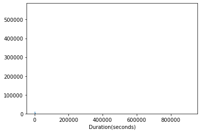

```python
bins=np.arange(0,df_clean.duration_sec.max()+100,100)
plt.hist(data=df_clean,x='duration_sec',bins=bins)
plt.xlabel('Duration(seconds)');
```

The above plot is almost blank indicating the presence extreme outliers. To better understand the distribution. We have to limit the axes

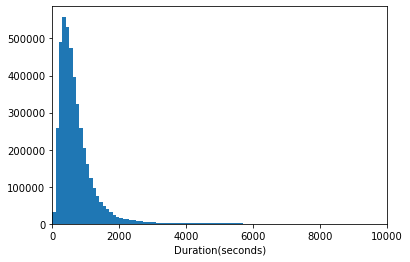

```python
bins=np.arange(0,df_clean.duration_sec.max()+100,100)
plt.hist(data=df_clean,x='duration_sec',bins=bins)
plt.xlabel('Duration(seconds)')
plt.xlim((0,10000));
```

The distribution is right skewed with a presence of large outliers.These include trips taking more than 2hrs. For the purpose of this analysis, only trip with duration less than 10000 seconds will be considered.Moreover since distribution is skewed, we will plot the distribution on log scale

```python
df_clean=df_clean.query('duration_sec<10000')
```

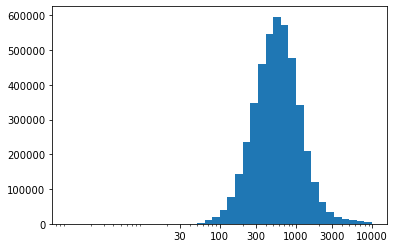

```python
#plotting on log scale
bins = 10 ** np.arange(0, np.log10(df_clean.duration_sec.max())+0.1, 0.1)
plt.hist(data=df_clean,x='duration_sec', bins = bins)
plt.xscale('log')
tick_locs = [30, 100, 300, 1000, 3000,10000]
plt.xticks(tick_locs, tick_locs);
```

The log scaled duration distribution looks almost normally distributed. The majority of trips seem to have duration between 100-3000seconds

**Next, the number of trips in each year, month and weekday will be seen**

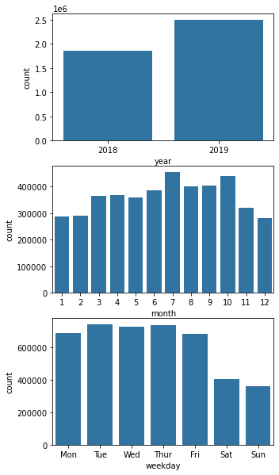

```python
fig, ax = plt.subplots(nrows=3, figsize = [5,10])
base_color = sb.color_palette()[0]

sb.countplot(data = df_clean, x = 'year', color = base_color, ax = ax[0])
sb.countplot(data = df_clean, x = 'month', color = base_color, ax = ax[1])
sb.countplot(data = df_clean, x = 'weekday', color = base_color, ax = ax[2])
plt.xticks((0,1,2,3,4,5,6),('Mon','Tue','Wed','Thur','Fri','Sat','Sun'));
```

The number of trips have increased from 2018 to 2019. There have been large number of trips in July and October. The interesting observation is that the number of trip on Weekends is considerably less than on Weekdays.

**The distributions of other features: user_type, bike_share_for_all_trip and rental_access_method will be explored next**

Since sb.countplot ignores null values bike_share_for_all_trip and rental_access_method can be plotted directly

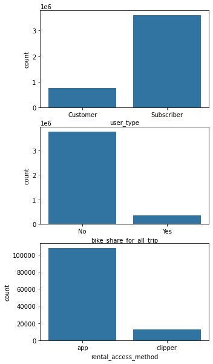

```python
fig, ax = plt.subplots(nrows=3, figsize = [5,10])
base_color = sb.color_palette()[0]

sb.countplot(data = df_clean, x = 'user_type', color = base_color, ax = ax[0])
sb.countplot(data = df_clean, x = 'bike_share_for_all_trip', color = base_color, ax = ax[1])
sb.countplot(data = df_clean, x = 'rental_access_method', color = base_color, ax = ax[2]);
```

It can be seen from the graph that subscribers tend to take a lot more trips than customers which makes intuitive sense. Among the trip data that has information on bike_share_for_all_trip, majority of trip don't share bikes for entire trip. Similarly, trips made using app are higher than clipper.

### Discuss the distribution(s) of your variable(s) of interest. Were there any unusual points? Did you need to perform any transformations?

The duration had wide range of data and was right skewed. Hence the log scaled distribution was studied. The log transformed distribution was similar to normal distribution. Majority of the trips had duration between 100 to 3000 seconds.

### Of the features you investigated, were there any unusual distributions? Did you perform any operations on the data to tidy, adjust, or change the form of the data? If so, why did you do this?

The duration variable had extreme large outliers. From the observation on graph as well as intuitive sense, the trips that had duration of more than 10000sec were deleted

## Bivariate Exploration

**Firstly, how the distribution of duration varies with each categorical variable will be observed**

```python
def violinplot(x, y):
    """ function for violinplot with a base color """
    base_color = sb.color_palette()[0]
    sb.violinplot(x, y, color = base_color)
```

```python
cat_vars=['year','month','weekday','user_type',
          'bike_share_for_all_trip','rental_access_method']
```

Violin plots will be plotted for each of the cat_vars mentioned above. The ylim will be set to 4000 as the duration_sec has extreme outliers

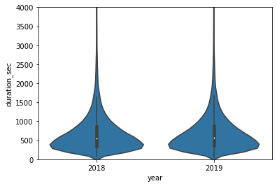

```python
violinplot(df_clean.year,df_clean.duration_sec)
plt.ylim((0,4000));
```

Both the years have almost similar distribution for duration. Hence this will not be explored further

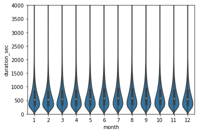

```python
violinplot(df_clean.month,df_clean.duration_sec)
plt.ylim((0,4000));
```

All the months have almost similar distribution for duration. Hence this will not be explored further

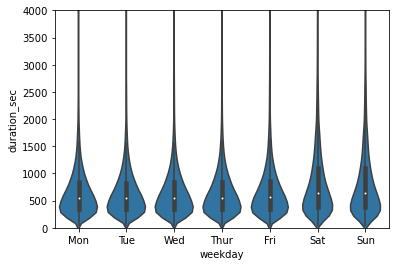

```python
violinplot(df_clean.weekday,df_clean.duration_sec)
plt.ylim((0,4000))
plt.xticks((0,1,2,3,4,5,6),('Mon','Tue','Wed','Thur','Fri','Sat','Sun'));
```

The durations seem to have shorter peaks and longer tails on weekends than weekdays. The mean duration on weekends is higher than on weekdays.This shows that there is higher probability for longer trips on weekends than on weekdays

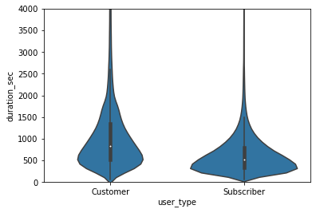

```python
violinplot(df_clean.user_type,df_clean.duration_sec)
plt.ylim((0,4000));
```

The trips taken by customers have shorter peaks and longer tails as compared to the trips taken by subscribers. The mean duration for customers is higher than for subscribers. This shows that customer user type more often takes longer trips than subscriber type

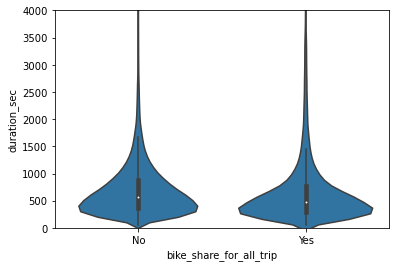

```python
violinplot(df_clean.bike_share_for_all_trip,df_clean.duration_sec)
plt.ylim((0,4000));
```

The durations has slightly shorter peaks and longer tails for trip using bike share for entire trip. However it is not very significant and means are almost same.

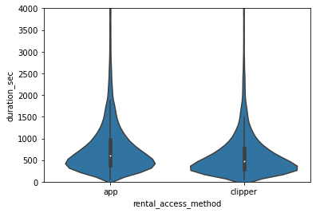

```python
violinplot(df_clean.rental_access_method,df_clean.duration_sec)
plt.ylim((0,4000));
```

App method of rental has slightly higher mean than than the clipper method.

**Now the relationship between categorical variables will be studied**

Plot will drawn for variation of user_type, bike_share_for_all_trip,rental_access_method with year,month and weekday

```python
def bivariate_subplots(x):

    """
    function to plot countplots of x along with year, month, and weekday
    """

    plt.figure(figsize = [10, 10])

    # subplot 1: year vs x
    plt.subplot(3, 1, 1)
    sb.countplot(data = df_clean, x = 'year', hue = x, palette = 'Blues')

    # subplot 2: month vs x
    ax = plt.subplot(3, 1, 2)
    sb.countplot(data = df_clean, x = 'month', hue = x, palette = 'Blues')
    ax.legend(ncol = 2)

    # subplot 3: weekday vs x
    ax = plt.subplot(3, 1, 3)
    sb.countplot(data = df_clean, x = 'weekday', hue = x, palette = 'Blues')
```

1. User Type

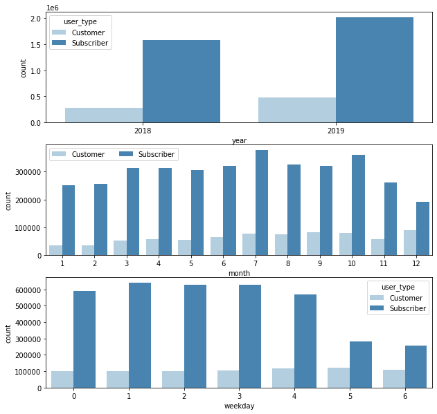

```python
bivariate_subplots('user_type')
```

The number of trips for both user types increased from 2018 to 2019. Except for few exceptions, the number of trips followed similar trend for both user types. An interesting observation is that though the number of trips made by subscriber user type decreased on weekends, the number of trips made by customer user type increased or stayed constant.

1. Bike share for all trip

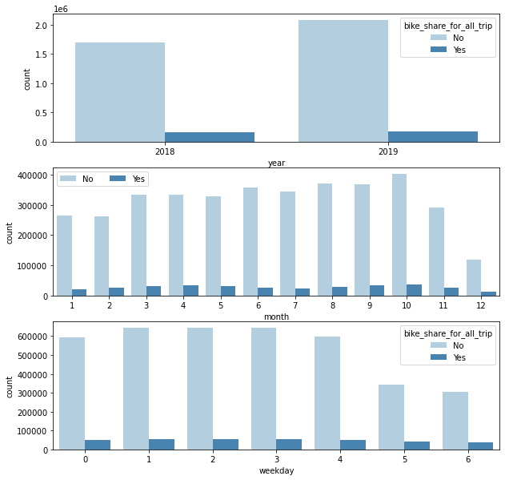

```python
bivariate_subplots('bike_share_for_all_trip')
```

The number of not all bike trips increased from 2018 to 2019 whereas all bike trips remained constant. Except for few exceptions, the number of both type trips followed similar trend. Both type of trips decreased on weekends as compared to weekdays. However decrease is higher for not all bike trips

1. Rental Access Method

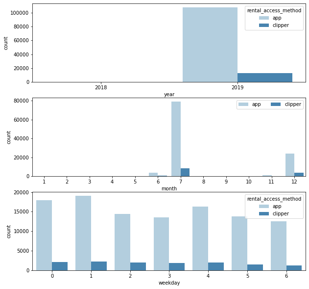

```python
bivariate_subplots('rental_access_method')
```

Now plots will drawn among user_type, bike_share_for_all_trip and rental access method

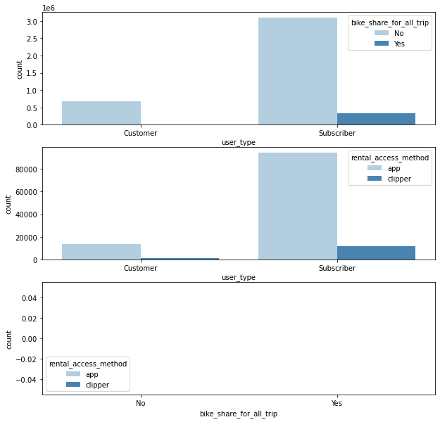

```python
plt.figure(figsize = [10, 10])

# subplot 1: year vs x
plt.subplot(3, 1, 1)
sb.countplot(data = df_clean, x = 'user_type',
             hue = 'bike_share_for_all_trip',palette = 'Blues')

# subplot 2: month vs x
ax = plt.subplot(3, 1, 2)
sb.countplot(data = df_clean, x = 'user_type',
             hue = 'rental_access_method', palette = 'Blues')

# subplot 3: weekday vs x
ax = plt.subplot(3, 1, 3)
sb.countplot(data = df_clean, x = 'bike_share_for_all_trip',
             hue = 'rental_access_method', palette = 'Blues');
```

```python
df_clean.query('bike_share_for_all_trip=="Yes"& user_type=="Customer"')
```

|  | duration_sec | start_time | end_time | start_station_id | start_station_name | start_station_latitude | start_station_longitude | end_station_id | end_station_name | end_station_latitude | end_station_longitude | bike_id | user_type | bike_share_for_all_trip | rental_access_method | year | month | weekday |
| --- | --- | --- | --- | --- | --- | --- | --- | --- | --- | --- | --- | --- | --- | --- | --- | --- | --- | --- |

There are no trips for which both the rental_access_method and bike_share_for_all_trip features are present. Hence no conclusion can be drawn about their relation. It is interesting that none of the customers took a shared bike trip. Subscribers took greater number of trips for both the rental methods

### Talk about some of the relationships you observed in this part of the investigation. How did the feature(s) of interest vary with other features in the dataset?

The most interesting observations are:

1. The durations have shorter peaks and longer tails on weekends than weekdays. The mean duration on weekends is higher than on weekdays.This shows that there is higher probability for longer trips on weekends than on weekdays
2. The trips taken by customers have shorter peaks and longer tails as compared to the trips taken by subscribers. The mean duration for customers is higher than for subscribers. This shows that customer user type more often takes longer trips than subscriber type
3. The durations has slightly shorter peaks and longer tails for trip using bike share for entire trip. However it is not very significant and means are almost same

### Did you observe any interesting relationships between the other features (not the main feature(s) of interest)?

The most interesting relationships found are

1. Though the number of trips made by subscriber user type decreased on weekends, the number of trips made by customer user type increased or stayed constant
2. None of the customers took a shared bike trip
3. The number of not all bike trips increased from 2018 to 2019 whereas all bike trips remained constant.

## Multivariate Exploration

Observing the bivariate plots, the main goal of this exploration has been set to understand the interaction among the variables: duration, user type and weekday

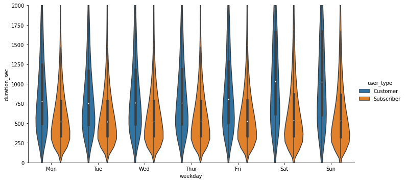

```python
sb.catplot(x="weekday", y="duration_sec", hue="user_type",
               data=df_clean, kind="violin",height=5, aspect=2)
plt.ylim((0,2000))
plt.xticks((0,1,2,3,4,5,6),('Mon','Tue','Wed','Thur','Fri','Sat','Sun'));
```

It can be seen that the mean duration of customer user type is higher than subscriber on each day.Moreover although the mean duration of subscribers remains almost constant, that for customers increases on weekend. For better visualization, a column will be created to show whether we have weekday or weekend.

```python
df_clean['weekend']=df_clean.weekday.apply(lambda x:'Weekend' if x==5 or x==6
                                          else 'Weekday')
```

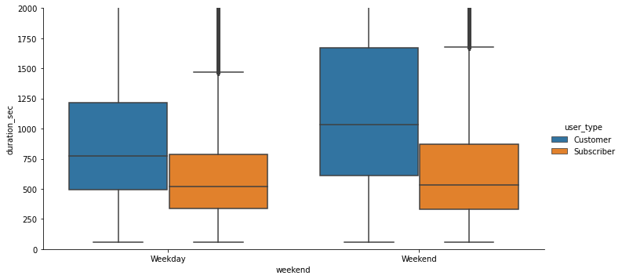

```python
sb.catplot(x="weekend", y="duration_sec", hue="user_type",
               data=df_clean, kind="box",height=5, aspect=2)
plt.ylim((0,2000));
```

From this graph it can be clearly seen that on both weekdays and weekends the mean duration of customers is greater than mean duration of subscribers. It is also evident that customers take longer trips on weekends than on weekdays whereas for subscribers such significant difference is not found

The variation of mean duration with weekend and bike_share_for_all_trip will be explored

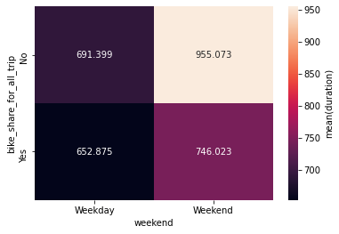

```python
cat_means = df_clean.groupby(['weekend', 'bike_share_for_all_trip']).mean()['duration_sec'].reset_index()
cat_means = cat_means.pivot(index = 'bike_share_for_all_trip',
                            columns = 'weekend',values = 'duration_sec')
sb.heatmap(cat_means, annot = True, fmt = '.3f',
           cbar_kws = {'label' : 'mean(duration)'});
```

Trips without bike share for entire trip had greater duration than trips without bike share for entire trip on both weekdays and weekends. However the difference is more pronounced on weekends than on weekdays

### Talk about some of the relationships you observed in this part of the investigation. Were there features that strengthened each other in terms of looking at your feature(s) of interest?

### Were there any interesting or surprising interactions between features?

1. The mean duration of customer user type is higher than subscriber on each day as expected from bivariate plots. It is interesting however that the mean duration of subscribers remains almost constant while that for customers increases on weekend.
2. From the bivariate plots, it was seen that bike share for entire trip had slightly lower duration than trips not using bike share for entire trip. However when interated with weekend dummy variable, it was seen the difference is greater on weekends than on weekdays